# dataThon

### DataThon!

[Data for Good](https://twitter.com/Data_for_Good) teaming up with [Raising the Roof](https://twitter.com/RaisingTheRoof) held a DataThon on Saturday in Toronto. I was glad to take part in it. It was 12-hour data crunching on about 20 data sets. In this post, we'll deal with one of them -- a donation Excel file. We're going to explore and clean it, create a new feature, and finally do donation frequency analysis.

### Take a look at the donation data

```python
import numpy as np
import pandas as pd
```

```python
class Display(object):
    """Display multiple objects horizontally"""
    template = """<div style="float: left; padding: 10px;">
                  <p>{0}</p><font size=2>{1}</font></div>
               """
    def __init__(self, *args):
        self.args = args

    def _repr_html_(self):
        return '\n'.join(self.template.format(a, eval(a)._repr_html_())
                         for a in self.args)
```

```python
df = pd.read_excel("donation.xlsx")
df.head()
```

|  | Expr1000 | ID | IncomeID | FundAccount | IncomeType | Payment Date | Payment Amount | Payment Method | Prefix | City1 | StateOrProvince1 | Postal Code | Area1 | TotalGifts | NumberOfGifts |
| --- | --- | --- | --- | --- | --- | --- | --- | --- | --- | --- | --- | --- | --- | --- | --- |
| 0 | 1 | 1 | 2419 | TQN | TQS | May-10-2001 | 25.0 | Cheque | Ms. | Ottawa | YT | K1R 5M8 | NaN | 540.01 | 8 |
| 1 | 1 | 1 | 63 | X | X | NaN | 75.0 | Cheque | Ms. | Ottawa | YT | K1R 5M8 | NaN | 540.01 | 8 |
| 2 | 1 | 1 | 7996 | TP | TPE | NaN | 0.0 | Cheque | Ms. | Ottawa | YT | K1R 5M8 | NaN | 540.01 | 8 |
| 3 | 1 | 1 | 2891 | GF | DN | NaN | 50.0 | Unknown | Ms. | Ottawa | YT | K1R 5M8 | NaN | 540.01 | 8 |
| 4 | 1 | 1 | 8325 | TP | HW | NaN | 0.0 | Money order | Ms. | Ottawa | YT | K1R 5M8 | NaN | 540.01 | 8 |

```python
df.shape
```

```
(9635, 15)
```

```python
df.ix[df.Expr1000 != df.ID].shape
```

```
(0, 15)
```

The columns `Expr1000` and `ID` have same values, and we use `ID` to identify donors.

For this post, we only use three columns as shown below.

```python
df = df[['ID', 'Prefix', 'Payment Date']]
df.columns = ['id', 'prefix', 'pay_date']  # rename columns
df.head()
```

|  | id | prefix | pay_date |
| --- | --- | --- | --- |
| 0 | 1 | Ms. | May-10-2001 |
| 1 | 1 | Ms. | NaN |
| 2 | 1 | Ms. | NaN |
| 3 | 1 | Ms. | NaN |
| 4 | 1 | Ms. | NaN |

```python
df.dtypes
```

```
id           int64
prefix      object
pay_date    object
dtype: object
```

### Clean the column `prefix`

```python
prefix = df.prefix.value_counts(dropna=False)
print("There are {} prefixes:\n\n{}".format(prefix.size, prefix))
```

```
There are 26 prefixes:

Mr.             3472
Ms.             3443
NaN             2090
Mrs.             369
Dr.               83
Mr. and Mrs.      58
Mr. & Mrs.        53
Ms                24
Rev.               9
Mr                 9
Miss               7
996                3
Mr. & Ms.          2
Mr & Mrs.          1
Miss.              1
MS                 1
Rabi               1
Ms.'               1
Father             1
Capt.              1
Hon.               1
Mrs                1
 Leora             1
Dr. & Mrs.         1
Mr. & Mrs          1
Mr.&Mrs.           1
Name: prefix, dtype: int64
```

The data is dirty in terms of one group having multiple values, e.g., 'Mr.' and 'Mr'. We can writing a Python dictionary to map prefixes to a few groups but it's tedious and not flexible; however, writing one big regular expression to deal with all the patterns is error-prone and hard to read.

> *Nothing is particularly hard if you divide it into small jobs.*

> *-- Henry Ford*

We'll use a **pipeline of regular expressions** to process the `prefix` column step by step.

**Step 1.** Replace missing values with `Unknown`.

```python
df['prefix'].fillna('Unknown', inplace=True)
```

**Step 2.** Map string including '&' or 'and' to 'Couple'

```python
df['prefix'].replace(r'^[DM].*(and|&).*', 'Couple', regex=True, inplace=True)
df.prefix.value_counts(dropna=False).sort_index()
```

```
 Leora        1
996           3
Capt.         1
Couple      117
Dr.          83
Father        1
Hon.          1
MS            1
Miss          7
Miss.         1
Mr            9
Mr.        3472
Mrs           1
Mrs.        369
Ms           24
Ms.        3443
Ms.'          1
Rabi          1
Rev.          9
Unknown    2090
Name: prefix, dtype: int64
```

**Step 3.** Map string beginning 'M' and including 's' or 'S' to 'F' (Female)

```python
df.prefix.replace(r'^M.*[sS].*', 'F', regex=True, inplace=True)
df.prefix.value_counts(dropna=False).sort_index()
```

```
 Leora        1
996           3
Capt.         1
Couple      117
Dr.          83
F          3847
Father        1
Hon.          1
Mr            9
Mr.        3472
Rabi          1
Rev.          9
Unknown    2090
Name: prefix, dtype: int64
```

**Step 4.** Map strings 'Mr', 'Mr.', and 'Father' to 'M' (Male)

```python
df.prefix.replace(r'^(Mr|Fa).*', 'M', regex=True, inplace=True)
df.prefix.value_counts().sort_index()
```

```
 Leora        1
996           3
Capt.         1
Couple      117
Dr.          83
F          3847
Hon.          1
M          3482
Rabi          1
Rev.          9
Unknown    2090
Name: prefix, dtype: int64
```

**Step 5.** Finaly map other strings to 'Other'

```python
df.prefix.replace(r'^(?!Couple|[FMU]).*', 'Other', regex=True, inplace=True)
df.prefix.value_counts().sort_index()
```

```
Couple      117
F          3847
M          3482
Other        99
Unknown    2090
Name: prefix, dtype: int64
```

```python
df.prefix.value_counts().sum() == df.shape[0]
```

```
True
```

```python
df.isnull().sum()
```

```
id             0
prefix         0
pay_date    1169
dtype: int64
```

We also see there are 1169 missing values in `pay_date`. Let's deal with them.

### Convert the column `pay_date` to datetime

First we're going to convert the column 'pay_date' from object to date type.

```python
pd.to_datetime(df.pay_date, format='%b-%d-%Y', errors='coerce').isnull().sum()
```

```
1202
```

We can see that besides 1169 missing values pandas convert other 33 (= 1202 - 1169) invalid strings to null, let's check what they are.

```python
try:
    pd.to_datetime(df.pay_date, format='%b-%d-%Y')
except Exception as inst:
    print(inst)
```

```
time data 'Feb-18-200' does not match format '%b-%d-%Y' (match)
```

The string 'Feb-18-200' is wrong with the year. Let's see how many this kind of data there are.

```python
filter_wrong_year = df.pay_date.notnull() & (df.pay_date.str.len() == 10)
wrong_year = df[filter_wrong_year]
print(wrong_year.head())
wrong_year.shape
```

```
        id prefix    pay_date
67      27      M  Feb-18-200
276    149      F  Feb-11-101
1277  1003      M  Mar-20-101
1625  1307      M  Jan-10-100
1908  1642      F  Feb-04-100
```

```
(28, 3)
```

We have found 28 of 33 invalid non-null strings. What are the remaining 5 (= 33 - 28)?

```python
filter_5 = df.pay_date.notnull() & (df.pay_date.str.len() != 10)
try:
    pd.to_datetime(df.ix[filter_5, 'pay_date'], format='%b-%d-%Y')
except Exception as inst:
    print(inst)
```

```
Out of bounds nanosecond timestamp: 8201-06-09 00:00:00
```

The year is 8201!

```python
pd.Timestamp.min, pd.Timestamp.max
```

```
(Timestamp('1677-09-21 00:12:43.145225'),
 Timestamp('2262-04-11 23:47:16.854775807'))
```

*(why pandas uses the two datetimes?)*

Let's check how many years are outside of pandas valid date range.

```python
df[(df.pay_date.str.len() != 10) &
   ((df.pay_date.str.slice(7, 11) > '2262') |
    (df.pay_date.str.slice(7, 11) < '1677'))]
```

|  | id | prefix | pay_date |
| --- | --- | --- | --- |
| 1440 | 1130 | Unknown | Jun-09-8201 |
| 3640 | 3061 | F | Nov-24-3003 |
| 4085 | 3303 | M | Aug-31-1201 |
| 7577 | 5604 | M | Jan-17-1201 |
| 8957 | 9704 | Unknown | Apr-04-4201 |

There are exactly 5 strings with invalid years. Having found all the 33 invalid date strings, we are now more confident about the conversion as shown below.

```python
df['pay_date'] = pd.to_datetime(df.pay_date, format='%b-%d-%Y', errors='coerce')
```

Pandas (and other tools) can't do everything for us. We need to do **further data integrity check**. Because Raising the Roof was launched in 1996, the payment dates earlier than 1996 or later than the data cutoff date should be treated as invalid data.

```python
min_date = pd.to_datetime('1996-01-01')
max_date = pd.to_datetime('2016-12-03') # we suppose today is the cutoff date

filter_biz = (df.pay_date < min_date) | (df.pay_date > max_date)
num_invalid_biz = df[filter_biz].shape[0]
print("There are {} dates violateing business rules.".format(num_invalid_biz))
Display('df[filter_biz].head()', 'df[filter_biz].tail()')
```

```
There are 826 dates violateing business rules.
```

df[filter_biz].head()

|  | id | prefix | pay_date |
| --- | --- | --- | --- |
| 10 | 1 | F | 1900-11-20 |
| 11 | 1 | F | 1900-11-20 |
| 19 | 3 | Unknown | 1900-12-01 |
| 20 | 3 | Unknown | 1900-03-03 |
| 45 | 22 | F | 1900-12-21 |

df[filter_biz].tail()

|  | id | prefix | pay_date |
| --- | --- | --- | --- |
| 3264 | 2831 | Unknown | 1901-02-02 |
| 3265 | 2832 | F | 1901-02-05 |
| 3267 | 2833 | F | 1901-08-13 |
| 7569 | 5604 | M | 2070-09-24 |
| 9550 | 10625 | Unknown | 2106-05-30 |

```python
num_null_before = df.pay_date.isnull().sum()
num_null_before
```

```
1202
```

We change the dates violating business rules to missing values.

```python
df.ix[filter_biz, ['pay_date']] = pd.NaT
```

```python
df.sort_values('pay_date', inplace=True)
Display('df[df.pay_date.notnull()].head()', 'df[df.pay_date.notnull()].tail()')
```

df[df.pay_date.notnull()].head()

|  | id | prefix | pay_date |
| --- | --- | --- | --- |
| 510 | 290 | F | 1997-11-09 |
| 561 | 313 | Unknown | 1998-01-01 |
| 517 | 290 | F | 1998-02-03 |
| 518 | 291 | M | 1998-02-24 |
| 479 | 262 | M | 1998-03-01 |

df[df.pay_date.notnull()].tail()

|  | id | prefix | pay_date |
| --- | --- | --- | --- |
| 9632 | 10732 | F | 2016-07-28 |
| 7248 | 5390 | M | 2016-07-31 |
| 8199 | 8512 | M | 2016-07-31 |
| 8933 | 9682 | Unknown | 2016-08-28 |
| 9634 | 10734 | M | 2016-09-08 |

```python
num_null_before, num_invalid_biz, df.pay_date.isnull().sum()
```

```
(1202, 826, 2028)
```

```python
df.isnull().sum()
```

```
id             0
prefix         0
pay_date    2028
dtype: int64
```

The number of nulls in `pay_date` changes from 1202 to 2028 after the additional 826 conversions.

### Create a new column 'active' to represent if donors are active

The business rule for counting active donors: a donor remains active for one year after the donating.

```python
min_active_date = df.pay_date.max() - pd.Timedelta('365 days')
min_active_date
```

```
Timestamp('2015-09-09 00:00:00')
```

We suppose a donor is active if the last date of her/his donating is later than 2015-09-08.

1: active; 0: not active

```python
df['active'] = np.where(df['pay_date'] >= min_active_date, 1, 0)
Display('df.head()', 'df.tail()', 'df[df.pay_date.notnull()].tail()')
```

df.head()

|  | id | prefix | pay_date | active |
| --- | --- | --- | --- | --- |
| 510 | 290 | F | 1997-11-09 | 0 |
| 561 | 313 | Unknown | 1998-01-01 | 0 |
| 517 | 290 | F | 1998-02-03 | 0 |
| 518 | 291 | M | 1998-02-24 | 0 |
| 479 | 262 | M | 1998-03-01 | 0 |

df.tail()

|  | id | prefix | pay_date | active |
| --- | --- | --- | --- | --- |
| 8737 | 9465 | Unknown | NaT | 0 |
| 8957 | 9704 | Unknown | NaT | 0 |
| 9343 | 10320 | Unknown | NaT | 0 |
| 9550 | 10625 | Unknown | NaT | 0 |
| 9597 | 10674 | F | NaT | 0 |

df[df.pay_date.notnull()].tail()

|  | id | prefix | pay_date | active |
| --- | --- | --- | --- | --- |
| 9632 | 10732 | F | 2016-07-28 | 1 |
| 7248 | 5390 | M | 2016-07-31 | 1 |
| 8199 | 8512 | M | 2016-07-31 | 1 |
| 8933 | 9682 | Unknown | 2016-08-28 | 1 |
| 9634 | 10734 | M | 2016-09-08 | 1 |

```python
df.active.value_counts()
```

```
0    9307
1     328
Name: active, dtype: int64
```

```python
df.pay_date.isnull().sum()
```

```
2028
```

How about these 2028 missing dates?

For null dates, we use **random integers with [0,1] discrete uniform distribution** to assign values to them.

```python
np.random.seed(0)
nr = np.random.randint(2, size=df.shape[0])
```

```python
df.active.where(df.pay_date.notnull(), nr, inplace=True)
```

```python
df.active.value_counts()
```

```
0    8248
1    1387
Name: active, dtype: int64
```

We can see 1387 is roughly equal to 328 + (2028 / 2), which means the distribution of the assigned values (0 or 1) for null pay_dates is almost uniform.

```python
Display('df.head()', 'df.tail()')
```

df.head()

|  | id | prefix | pay_date | active |
| --- | --- | --- | --- | --- |
| 510 | 290 | F | 1997-11-09 | 0 |
| 561 | 313 | Unknown | 1998-01-01 | 0 |
| 517 | 290 | F | 1998-02-03 | 0 |
| 518 | 291 | M | 1998-02-24 | 0 |
| 479 | 262 | M | 1998-03-01 | 0 |

df.tail()

|  | id | prefix | pay_date | active |
| --- | --- | --- | --- | --- |
| 8737 | 9465 | Unknown | NaT | 0 |
| 8957 | 9704 | Unknown | NaT | 0 |
| 9343 | 10320 | Unknown | NaT | 1 |
| 9550 | 10625 | Unknown | NaT | 0 |
| 9597 | 10674 | F | NaT | 0 |

### Donation frequency analysis

Some donors donate many times; some only once. What percents of donors donate once, twice, or N times? It's acutally a time-to-event (also called survival analysis) question. Let's try to answer it.

```python
donation_freq = df.groupby(['id'])
donation_freq
```

```
<pandas.core.groupby.DataFrameGroupBy object at 0x0000021E01972278>
```

```python
rows = []
for donor_id, group in donation_freq:  # group is DataFrame
    rows.append((donor_id, group.shape[0], group.prefix.values[0], group.active.max(),
                 pd.NaT if group.pay_date.isnull().any() else group.pay_date.max()))
rows[:5]
```

```
[(1, 17, 'F', 1, NaT),
 (2, 1, 'Unknown', 1, NaT),
 (3, 3, 'Unknown', 1, NaT),
 (4, 3, 'F', 1, NaT),
 (5, 4, 'F', 1, NaT)]
```

```python
df_freq = pd.DataFrame(rows, columns=['donor_id', 'freq', 'group','active', 'last_pay_date'])
df_freq.sort_values('freq', ascending=False, inplace=True)
Display('df_freq.head()', 'df_freq.tail()')
```

df_freq.head()

|  | donor_id | freq | group | active | last_pay_date |
| --- | --- | --- | --- | --- | --- |
| 4665 | 5604 | 40 | M | 1 | NaT |
| 2366 | 3156 | 38 | Unknown | 1 | NaT |
| 2085 | 2837 | 26 | Unknown | 1 | NaT |
| 550 | 999 | 25 | Unknown | 1 | NaT |
| 46 | 70 | 24 | M | 1 | NaT |

df_freq.tail()

|  | donor_id | freq | group | active | last_pay_date |
| --- | --- | --- | --- | --- | --- |
| 2306 | 3077 | 1 | M | 0 | 2003-11-24 |
| 2305 | 3076 | 1 | M | 0 | 2003-11-24 |
| 2304 | 3075 | 1 | M | 0 | 2003-11-24 |
| 2303 | 3074 | 1 | F | 0 | 2003-11-24 |
| 6322 | 10734 | 1 | M | 1 | 2016-09-08 |

```python
df_freq.shape
```

```
(6323, 5)
```

```python
df_freq.freq.sum() == df.shape[0]
```

```
True
```

We'll use a survival analysis package called `kmsurvival` to do the donation frequency analysis.

`$ pip install kmsurvival`

```python
from kmsurvival import KMSurvival
%matplotlib inline
```

```python
cutoff = df_freq.last_pay_date.max().strftime('%Y-%m-%d')
kms = KMSurvival(col_censored='active',
                 col_tenure='freq')
estimates = kms.fit(df_freq, cutoff)
Display('estimates.head()', 'estimates.tail()')
```

estimates.head()

| estimates_ _tenure_ | survival | hazard | cnt_uncensored | cnt_censored | cutoff |
| --- | --- | --- | --- | --- | --- |
| 1 | 0.337814 | 0.662186 | 4187 | 877 | 2016-09-08 |
| 2 | 0.206338 | 0.389198 | 490 | 154 | 2016-09-08 |
| 3 | 0.150979 | 0.268293 | 165 | 82 | 2016-09-08 |
| 4 | 0.120209 | 0.203804 | 75 | 43 | 2016-09-08 |
| 5 | 0.096167 | 0.200000 | 50 | 22 | 2016-09-08 |

estimates.tail()

| estimates_ _tenure_ | survival | hazard | cnt_uncensored | cnt_censored | cutoff |
| --- | --- | --- | --- | --- | --- |
| 24 | 0.025961 | 0.166667 | 1 | 1 | 2016-09-08 |
| 25 | 0.025961 | 0.000000 | 0 | 1 | 2016-09-08 |
| 26 | 0.025961 | 0.000000 | 0 | 1 | 2016-09-08 |
| 38 | 0.025961 | 0.000000 | 0 | 1 | 2016-09-08 |
| 40 | 0.025961 | 0.000000 | 0 | 1 | 2016-09-08 |

```python
kms.cutoff
```

```
'2016-09-08'
```

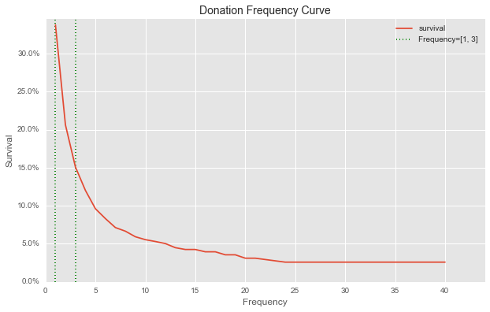

```python
title='Donation Frequency Curve'
xlabel='Frequency'
kms.plot(title=title,
         xlabel=xlabel,
         vlines=[1, 3],
         figsize=(10, 6),
         style='ggplot')
```

From the figure above, we can see:

- about 34% donors have donated more than one time -- that also means that about 66% donors just donate once and then stop donating.
- 15% donors have donated more than three times.
- about 2.5% donors have donated more than 24 times and still active, which means it is possible that they will donate again.

Let's compare among groups.

```python
kms.fit(df_freq, cutoff, group=['group'])
kms.subgrps_
```

```
OrderedDict([('group', ('M', 'Unknown', 'F', 'Couple', 'Other'))])
```

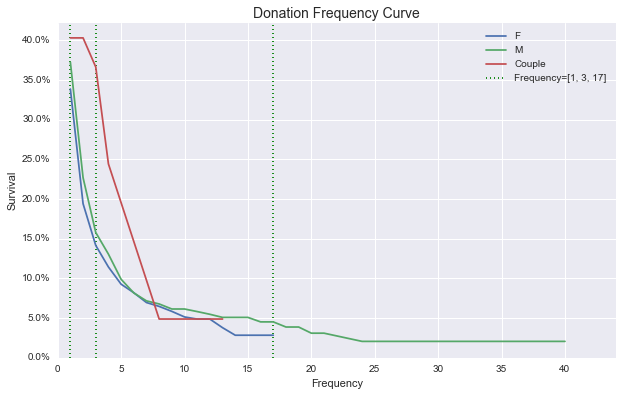

```python
kms.plot(strata=[['F', 'M', 'Couple']],
         title=title, xlabel=xlabel,
         figsize=(10, 6), vlines=[1, 3, 17])
```

From the comparisons, we can get some interesting information.

- The couple donors have the highest 'survival' probabilities, which means it is more possible for couples to donate more times than single donors.
- The male donors are a little higher than the female ones in terms of the probabilities of donating more times.
- Only the male donors have donated more than 17 times and still be active.

### Summary

- We often say "know your data". It's acutally about knowing the business behind data. I took almost half of the day to figure out what the data means, but it was worth the time.
- The real data is not neat, just as the real world.
- We learn from each other in a team. And produce results **early and often** so you have something to talk about and get timely feedback. Iterate data analysis quickly.
- How to deal with missing values, how to create derived features, and how to come up with the right set of variables for modeling? To answer these questions needs experience and business knowledge. They are the art part of data science as [the tweet](https://twitter.com/j_houg/status/709470269916598276) says:

[figure not shown]

What a day!

Thanks for reading!